# Okruhy k SZZ

## Úkol 1

Údaje jsou vypsány pouze pro prvních 5 studentů (dle abecedy), více lze vypsat změnou podmínky for cyklu

KI/SZZTP: Teoretické základy informatiky (Beneš Jakub)

| 1 | 1 | Základní abstraktní kolekce a specializované abstraktní kolekce |
| --- | --- | --- |
| 2 | 2 | Komplexní algoritmy nad seznamy, vyhledávání a třídění |
| 3 | 3 | Spojové datové struktury a základní operace nad nimi |
| 4 | 4 | Reálná funkce jedné reálné proměnné, polynomy, numerické řešení nelineárních rovnic |
| 5 | 5 | Diferenciální a integrální počet funkcí jedné proměnné, numerické derivování a integrace |
| 6 | 6 | Soustava lineárních rovnic |
| 7 | 7 | Reálná funkce více reálných proměnných, aproximace metodou nejmenších čtverců |
| 8 | 8 | Náhodná veličina a její charakteristiky |
| 9 | 9 | Intervaly spolehlivosti |
| 10 | 10 | Výrokový počet, predikátový počet, naivní teorie množin, binární relace |
| 11 | 11 | Rekurence, speciální funkce, asymptotická notace, algoritmy |
| 12 | 12 | Grafy, stromy, eulerovské a hamiltonovské grafy, prohledávání do hloubky a do šířky |

KI/SZZPP: Aplikovaná informatika – povinný základ (Beneš Jakub)

| 1 | 1 | Algoritmizace a programování I a II: funkce a cykly |
| --- | --- | --- |
| 2 | 2 | Algoritmizace a programování I a II: kolekce |
| 3 | 3 | Algoritmizace a programování I a II: základy OOP |
| 4 | 4 | Architektura počítačů: výběr komponent počítače |
| 5 | 5 | Architektura počítačů: diagnostika a řešení problémů |
|  | 6 | Základy elektroniky: analogová část |
|  | 7 | Základy elektroniky: digitální část |
| 6 | 8 | Základy počítačových sítí a protokolů: návrh počítačové sítě |
| 7 | 9 | Základy počítačových sítí a protokolů: konfigurace počítačové sítě |
| 8 | 10 | Matematický software |
| 9 | 11 | Operační systémy |
| 10 | 12 | Úvod do relačních databází |
| 11 | 13 | Základy kyberbezpečnosti |
| 12 | 14 | Základy zpracování dat |
| 13 | 15 | Multimédia a základy počítačové grafiky |
| 14 | 16 | Projektové řízení |

KI/SZZVP: Aplikovaná informatika – volitelné bloky (Beneš Jakub)

| 1 | 1 | Relační databázové systémy a OLAP databáze |
| --- | --- | --- |
|  | 2 | NoSQL databáze |
|  | 3 | Počítačové zpracování signálu |
| 2 | 4 | Pokročilé statistické metody a zpracování časových řad |
| 3 | 5 | Úvod do strojového učení |
|  | 6 | Elektronika a automatizace A |
| 4 | 7 | Elektronika a automatizace B |
|  | 8 | Elektronika a automatizace C |
|  | 9 | Elektronika a automatizace D |
|  | 10 | Elektronika a automatizace E |
|  | 11 | Kryptologie |
| 5 | 12 | Technologie pro security operations center |
| 6 | 13 | Penetrační testování |
| 7 | 14 | Návrh modernizace infrastruktury IT |
|  | 15 | Realizace infrastruktury IT |
| 8 | 16 | Administrace operačních systémů |
|  | 17 | Vytvoření počítačové sítě |
|  | 18 | Troubleshooting počítačové sítě |
|  | 19 | Monitoring počítačové sítě |
|  | 20 | Analýza a vizualizace dat z podnikových informačních systémů |
| 9 | 21 | Optimální rozhodování |
|  | 22 | Mikroekonomie a makroekonomie, stochastické modelování |
| 10 | 23 | Objektově orientované návrhové vzory |
|  | 24 | Vývoj desktopové aplikace |
| 11 | 25 | Vývoj webové aplikace |
| 12 | 26 | Objektově orientovaný návrh |
| 13 | 27 | Vývoj mobilní aplikace |

KI/SZZTP: Teoretické základy informatiky (Dvořák Barbora)

| 1 | 1 | Základní abstraktní kolekce a specializované abstraktní kolekce |
| --- | --- | --- |
| 2 | 2 | Komplexní algoritmy nad seznamy, vyhledávání a třídění |
| 3 | 3 | Spojové datové struktury a základní operace nad nimi |
| 4 | 4 | Reálná funkce jedné reálné proměnné, polynomy, numerické řešení nelineárních rovnic |
| 5 | 5 | Diferenciální a integrální počet funkcí jedné proměnné, numerické derivování a integrace |
| 6 | 6 | Soustava lineárních rovnic |
| 7 | 7 | Reálná funkce více reálných proměnných, aproximace metodou nejmenších čtverců |
| 8 | 8 | Náhodná veličina a její charakteristiky |
| 9 | 9 | Intervaly spolehlivosti |
| 10 | 10 | Výrokový počet, predikátový počet, naivní teorie množin, binární relace |
| 11 | 11 | Rekurence, speciální funkce, asymptotická notace, algoritmy |
| 12 | 12 | Grafy, stromy, eulerovské a hamiltonovské grafy, prohledávání do hloubky a do šířky |

KI/SZZPP: Aplikovaná informatika – povinný základ (Dvořák Barbora)

| 1 | 1 | Algoritmizace a programování I a II: funkce a cykly |
| --- | --- | --- |
| 2 | 2 | Algoritmizace a programování I a II: kolekce |
| 3 | 3 | Algoritmizace a programování I a II: základy OOP |
| 4 | 4 | Architektura počítačů: výběr komponent počítače |
| 5 | 5 | Architektura počítačů: diagnostika a řešení problémů |
|  | 6 | Základy elektroniky: analogová část |
|  | 7 | Základy elektroniky: digitální část |
| 6 | 8 | Základy počítačových sítí a protokolů: návrh počítačové sítě |
| 7 | 9 | Základy počítačových sítí a protokolů: konfigurace počítačové sítě |
| 8 | 10 | Matematický software |
| 9 | 11 | Operační systémy |
| 10 | 12 | Úvod do relačních databází |
| 11 | 13 | Základy kyberbezpečnosti |
| 12 | 14 | Základy zpracování dat |
| 13 | 15 | Multimédia a základy počítačové grafiky |
| 14 | 16 | Projektové řízení |

KI/SZZVP: Aplikovaná informatika – volitelné bloky (Dvořák Barbora)

| 1 | 1 | Relační databázové systémy a OLAP databáze |
| --- | --- | --- |
|  | 2 | NoSQL databáze |
|  | 3 | Počítačové zpracování signálu |
| 2 | 4 | Pokročilé statistické metody a zpracování časových řad |
| 3 | 5 | Úvod do strojového učení |
|  | 6 | Elektronika a automatizace A |
| 4 | 7 | Elektronika a automatizace B |
|  | 8 | Elektronika a automatizace C |
|  | 9 | Elektronika a automatizace D |
|  | 10 | Elektronika a automatizace E |
|  | 11 | Kryptologie |
| 5 | 12 | Technologie pro security operations center |
| 6 | 13 | Penetrační testování |
| 7 | 14 | Návrh modernizace infrastruktury IT |
|  | 15 | Realizace infrastruktury IT |
| 8 | 16 | Administrace operačních systémů |
|  | 17 | Vytvoření počítačové sítě |
|  | 18 | Troubleshooting počítačové sítě |
|  | 19 | Monitoring počítačové sítě |
|  | 20 | Analýza a vizualizace dat z podnikových informačních systémů |
| 9 | 21 | Optimální rozhodování |
|  | 22 | Mikroekonomie a makroekonomie, stochastické modelování |
| 10 | 23 | Objektově orientované návrhové vzory |
|  | 24 | Vývoj desktopové aplikace |
| 11 | 25 | Vývoj webové aplikace |
| 12 | 26 | Objektově orientovaný návrh |
| 13 | 27 | Vývoj mobilní aplikace |

KI/SZZTP: Teoretické základy informatiky (Dvořák Jan)

| 1 | 1 | Základní abstraktní kolekce a specializované abstraktní kolekce |
| --- | --- | --- |
| 2 | 2 | Komplexní algoritmy nad seznamy, vyhledávání a třídění |
| 3 | 3 | Spojové datové struktury a základní operace nad nimi |
| 4 | 4 | Reálná funkce jedné reálné proměnné, polynomy, numerické řešení nelineárních rovnic |
| 5 | 5 | Diferenciální a integrální počet funkcí jedné proměnné, numerické derivování a integrace |
| 6 | 6 | Soustava lineárních rovnic |
| 7 | 7 | Reálná funkce více reálných proměnných, aproximace metodou nejmenších čtverců |
| 8 | 8 | Náhodná veličina a její charakteristiky |
| 9 | 9 | Intervaly spolehlivosti |
| 10 | 10 | Výrokový počet, predikátový počet, naivní teorie množin, binární relace |
| 11 | 11 | Rekurence, speciální funkce, asymptotická notace, algoritmy |
| 12 | 12 | Grafy, stromy, eulerovské a hamiltonovské grafy, prohledávání do hloubky a do šířky |

KI/SZZPP: Aplikovaná informatika – povinný základ (Dvořák Jan)

| 1 | 1 | Algoritmizace a programování I a II: funkce a cykly |
| --- | --- | --- |
| 2 | 2 | Algoritmizace a programování I a II: kolekce |
| 3 | 3 | Algoritmizace a programování I a II: základy OOP |
| 4 | 4 | Architektura počítačů: výběr komponent počítače |
| 5 | 5 | Architektura počítačů: diagnostika a řešení problémů |
|  | 6 | Základy elektroniky: analogová část |
|  | 7 | Základy elektroniky: digitální část |
| 6 | 8 | Základy počítačových sítí a protokolů: návrh počítačové sítě |
| 7 | 9 | Základy počítačových sítí a protokolů: konfigurace počítačové sítě |
| 8 | 10 | Matematický software |
| 9 | 11 | Operační systémy |
| 10 | 12 | Úvod do relačních databází |
| 11 | 13 | Základy kyberbezpečnosti |
| 12 | 14 | Základy zpracování dat |
| 13 | 15 | Multimédia a základy počítačové grafiky |
| 14 | 16 | Projektové řízení |

KI/SZZVP: Aplikovaná informatika – volitelné bloky (Dvořák Jan)

| 1 | 1 | Relační databázové systémy a OLAP databáze |
| --- | --- | --- |
|  | 2 | NoSQL databáze |
|  | 3 | Počítačové zpracování signálu |
| 2 | 4 | Pokročilé statistické metody a zpracování časových řad |
| 3 | 5 | Úvod do strojového učení |
|  | 6 | Elektronika a automatizace A |
| 4 | 7 | Elektronika a automatizace B |
|  | 8 | Elektronika a automatizace C |
|  | 9 | Elektronika a automatizace D |
|  | 10 | Elektronika a automatizace E |
|  | 11 | Kryptologie |
| 5 | 12 | Technologie pro security operations center |
| 6 | 13 | Penetrační testování |
| 7 | 14 | Návrh modernizace infrastruktury IT |
|  | 15 | Realizace infrastruktury IT |
| 8 | 16 | Administrace operačních systémů |
|  | 17 | Vytvoření počítačové sítě |
|  | 18 | Troubleshooting počítačové sítě |
|  | 19 | Monitoring počítačové sítě |
|  | 20 | Analýza a vizualizace dat z podnikových informačních systémů |
| 9 | 21 | Optimální rozhodování |
|  | 22 | Mikroekonomie a makroekonomie, stochastické modelování |
| 10 | 23 | Objektově orientované návrhové vzory |
|  | 24 | Vývoj desktopové aplikace |
| 11 | 25 | Vývoj webové aplikace |
| 12 | 26 | Objektově orientovaný návrh |
| 13 | 27 | Vývoj mobilní aplikace |

KI/SZZTP: Teoretické základy informatiky (Dvořák Petr)

| 1 | 1 | Základní abstraktní kolekce a specializované abstraktní kolekce |
| --- | --- | --- |
| 2 | 2 | Komplexní algoritmy nad seznamy, vyhledávání a třídění |
| 3 | 3 | Spojové datové struktury a základní operace nad nimi |
| 4 | 4 | Reálná funkce jedné reálné proměnné, polynomy, numerické řešení nelineárních rovnic |
| 5 | 5 | Diferenciální a integrální počet funkcí jedné proměnné, numerické derivování a integrace |
| 6 | 6 | Soustava lineárních rovnic |
| 7 | 7 | Reálná funkce více reálných proměnných, aproximace metodou nejmenších čtverců |
| 8 | 8 | Náhodná veličina a její charakteristiky |
| 9 | 9 | Intervaly spolehlivosti |
| 10 | 10 | Výrokový počet, predikátový počet, naivní teorie množin, binární relace |
| 11 | 11 | Rekurence, speciální funkce, asymptotická notace, algoritmy |
| 12 | 12 | Grafy, stromy, eulerovské a hamiltonovské grafy, prohledávání do hloubky a do šířky |

KI/SZZPP: Aplikovaná informatika – povinný základ (Dvořák Petr)

| 1 | 1 | Algoritmizace a programování I a II: funkce a cykly |
| --- | --- | --- |
| 2 | 2 | Algoritmizace a programování I a II: kolekce |
| 3 | 3 | Algoritmizace a programování I a II: základy OOP |
| 4 | 4 | Architektura počítačů: výběr komponent počítače |
| 5 | 5 | Architektura počítačů: diagnostika a řešení problémů |
|  | 6 | Základy elektroniky: analogová část |
|  | 7 | Základy elektroniky: digitální část |
| 6 | 8 | Základy počítačových sítí a protokolů: návrh počítačové sítě |
| 7 | 9 | Základy počítačových sítí a protokolů: konfigurace počítačové sítě |
| 8 | 10 | Matematický software |
| 9 | 11 | Operační systémy |
| 10 | 12 | Úvod do relačních databází |
| 11 | 13 | Základy kyberbezpečnosti |
| 12 | 14 | Základy zpracování dat |
| 13 | 15 | Multimédia a základy počítačové grafiky |
| 14 | 16 | Projektové řízení |

KI/SZZVP: Aplikovaná informatika – volitelné bloky (Dvořák Petr)

| 1 | 1 | Relační databázové systémy a OLAP databáze |
| --- | --- | --- |
|  | 2 | NoSQL databáze |
|  | 3 | Počítačové zpracování signálu |
| 2 | 4 | Pokročilé statistické metody a zpracování časových řad |
| 3 | 5 | Úvod do strojového učení |
|  | 6 | Elektronika a automatizace A |
| 4 | 7 | Elektronika a automatizace B |
|  | 8 | Elektronika a automatizace C |
|  | 9 | Elektronika a automatizace D |
|  | 10 | Elektronika a automatizace E |
|  | 11 | Kryptologie |
| 5 | 12 | Technologie pro security operations center |
| 6 | 13 | Penetrační testování |
| 7 | 14 | Návrh modernizace infrastruktury IT |
|  | 15 | Realizace infrastruktury IT |
| 8 | 16 | Administrace operačních systémů |
|  | 17 | Vytvoření počítačové sítě |
|  | 18 | Troubleshooting počítačové sítě |
|  | 19 | Monitoring počítačové sítě |
|  | 20 | Analýza a vizualizace dat z podnikových informačních systémů |
| 9 | 21 | Optimální rozhodování |
|  | 22 | Mikroekonomie a makroekonomie, stochastické modelování |
| 10 | 23 | Objektově orientované návrhové vzory |
|  | 24 | Vývoj desktopové aplikace |
| 11 | 25 | Vývoj webové aplikace |
| 12 | 26 | Objektově orientovaný návrh |
| 13 | 27 | Vývoj mobilní aplikace |

KI/SZZTP: Teoretické základy informatiky (Fiala Eva)

| 1 | 1 | Základní abstraktní kolekce a specializované abstraktní kolekce |
| --- | --- | --- |
| 2 | 2 | Komplexní algoritmy nad seznamy, vyhledávání a třídění |
| 3 | 3 | Spojové datové struktury a základní operace nad nimi |
| 4 | 4 | Reálná funkce jedné reálné proměnné, polynomy, numerické řešení nelineárních rovnic |
| 5 | 5 | Diferenciální a integrální počet funkcí jedné proměnné, numerické derivování a integrace |
| 6 | 6 | Soustava lineárních rovnic |
| 7 | 7 | Reálná funkce více reálných proměnných, aproximace metodou nejmenších čtverců |
| 8 | 8 | Náhodná veličina a její charakteristiky |
| 9 | 9 | Intervaly spolehlivosti |
| 10 | 10 | Výrokový počet, predikátový počet, naivní teorie množin, binární relace |
| 11 | 11 | Rekurence, speciální funkce, asymptotická notace, algoritmy |
| 12 | 12 | Grafy, stromy, eulerovské a hamiltonovské grafy, prohledávání do hloubky a do šířky |

KI/SZZPP: Aplikovaná informatika – povinný základ (Fiala Eva)

| 1 | 1 | Algoritmizace a programování I a II: funkce a cykly |
| --- | --- | --- |
| 2 | 2 | Algoritmizace a programování I a II: kolekce |
| 3 | 3 | Algoritmizace a programování I a II: základy OOP |
| 4 | 4 | Architektura počítačů: výběr komponent počítače |
| 5 | 5 | Architektura počítačů: diagnostika a řešení problémů |
|  | 6 | Základy elektroniky: analogová část |
|  | 7 | Základy elektroniky: digitální část |
| 6 | 8 | Základy počítačových sítí a protokolů: návrh počítačové sítě |
| 7 | 9 | Základy počítačových sítí a protokolů: konfigurace počítačové sítě |
| 8 | 10 | Matematický software |
| 9 | 11 | Operační systémy |
| 10 | 12 | Úvod do relačních databází |
| 11 | 13 | Základy kyberbezpečnosti |
| 12 | 14 | Základy zpracování dat |
| 13 | 15 | Multimédia a základy počítačové grafiky |
| 14 | 16 | Projektové řízení |

KI/SZZVP: Aplikovaná informatika – volitelné bloky (Fiala Eva)

| 1 | 1 | Relační databázové systémy a OLAP databáze |
| --- | --- | --- |
|  | 2 | NoSQL databáze |
|  | 3 | Počítačové zpracování signálu |
| 2 | 4 | Pokročilé statistické metody a zpracování časových řad |
| 3 | 5 | Úvod do strojového učení |
|  | 6 | Elektronika a automatizace A |
| 4 | 7 | Elektronika a automatizace B |
|  | 8 | Elektronika a automatizace C |
|  | 9 | Elektronika a automatizace D |
|  | 10 | Elektronika a automatizace E |
|  | 11 | Kryptologie |
| 5 | 12 | Technologie pro security operations center |
| 6 | 13 | Penetrační testování |
| 7 | 14 | Návrh modernizace infrastruktury IT |
|  | 15 | Realizace infrastruktury IT |
| 8 | 16 | Administrace operačních systémů |
|  | 17 | Vytvoření počítačové sítě |
|  | 18 | Troubleshooting počítačové sítě |
|  | 19 | Monitoring počítačové sítě |
|  | 20 | Analýza a vizualizace dat z podnikových informačních systémů |
| 9 | 21 | Optimální rozhodování |
|  | 22 | Mikroekonomie a makroekonomie, stochastické modelování |
| 10 | 23 | Objektově orientované návrhové vzory |
|  | 24 | Vývoj desktopové aplikace |
| 11 | 25 | Vývoj webové aplikace |
| 12 | 26 | Objektově orientovaný návrh |
| 13 | 27 | Vývoj mobilní aplikace |

## Úkol 2

### Počty zvolení otázek v rámci SZZTP

| Komplexní algoritmy nad seznamy, vyhledávání a třídění | 93 |
| --- | --- |
| Základní abstraktní kolekce a specializované abstraktní kolekce | 92 |
| Rekurence, speciální funkce, asymptotická notace, algoritmy | 88 |
| Grafy, stromy, eulerovské a hamiltonovské grafy, prohledávání do hloubky a do šířky | 88 |
| Spojové datové struktury a základní operace nad nimi | 84 |
| Diferenciální a integrální počet funkcí jedné proměnné, numerické derivování a integrace | 84 |
| Soustava lineárních rovnic | 82 |
| Reálná funkce jedné reálné proměnné, polynomy, numerické řešení nelineárních rovnic | 81 |
| Náhodná veličina a její charakteristiky | 81 |
| Výrokový počet, predikátový počet, naivní teorie množin, binární relace | 79 |
| Reálná funkce více reálných proměnných, aproximace metodou nejmenších čtverců | 75 |
| Intervaly spolehlivosti | 73 |

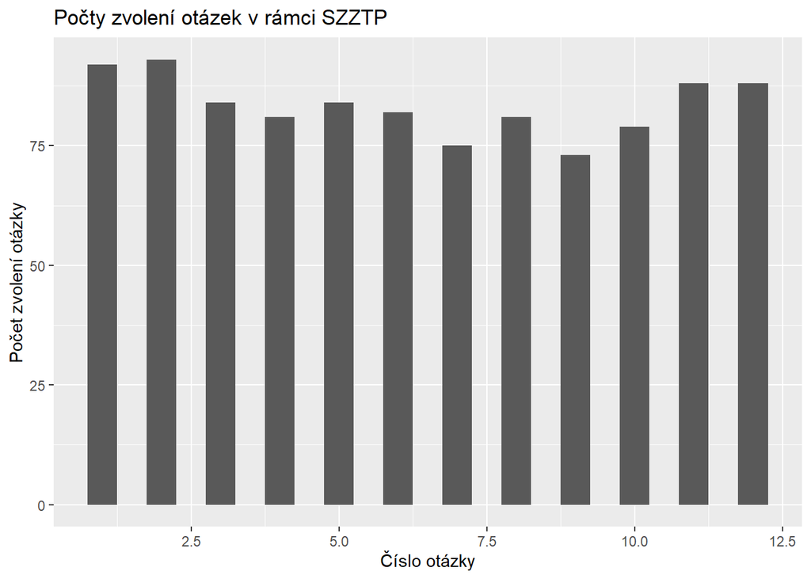

V rámci SZZTP byla nejoblíbenější otázka číslo 2. Nejméně oblíbené byly otázky:

| Intervaly spolehlivosti | 73 |
| --- | --- |
| Reálná funkce více reálných proměnných, aproximace metodou nejmenších čtverců | 75 |
| Výrokový počet, predikátový počet, naivní teorie množin, binární relace | 79 |
| Reálná funkce jedné reálné proměnné, polynomy, numerické řešení nelineárních rovnic | 81 |
| Náhodná veličina a její charakteristiky | 81 |

### Počty zvolení otázek v rámci SZZPP

| Základy zpracování dat | 91 |
| --- | --- |
| Algoritmizace a programování I a II: základy OOP | 90 |
| Úvod do relačních databází | 90 |
| Algoritmizace a programování I a II: kolekce | 88 |
| Základy kyberbezpečnosti | 88 |
| Multimédia a základy počítačové grafiky | 88 |
| Algoritmizace a programování I a II: funkce a cykly | 85 |
| Architektura počítačů: výběr komponent počítače | 77 |
| Základy počítačových sítí a protokolů: konfigurace počítačové sítě | 76 |
| Operační systémy | 75 |
| Základy počítačových sítí a protokolů: návrh počítačové sítě | 72 |
| Projektové řízení | 70 |
| Architektura počítačů: diagnostika a řešení problémů | 64 |
| Matematický software | 56 |
| Základy elektroniky: digitální část | 54 |
| Základy elektroniky: analogová část | 36 |

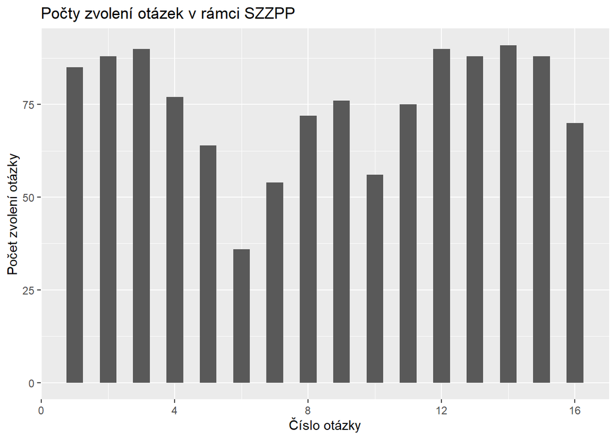

Nejméně oblíbené byly otázky:

| Základy elektroniky: analogová část | 36 |
| --- | --- |
| Základy elektroniky: digitální část | 54 |
| Matematický software | 56 |
| Architektura počítačů: diagnostika a řešení problémů | 64 |
| Projektové řízení | 70 |

### Počty zvolení otázek v rámci SZZVP

| Objektově orientované návrhové vzory | 50 |
| --- | --- |
| Úvod do strojového učení | 49 |
| Objektově orientovaný návrh | 47 |
| Analýza a vizualizace dat z podnikových informačních systémů | 43 |
| Vývoj mobilní aplikace | 43 |
| Vývoj webové aplikace | 42 |
| NoSQL databáze | 40 |
| Relační databázové systémy a OLAP databáze | 38 |
| Technologie pro security operations center | 38 |
| Troubleshooting počítačové sítě | 38 |
| Návrh modernizace infrastruktury IT | 34 |
| Penetrační testování | 32 |
| Administrace operačních systémů | 30 |
| Vytvoření počítačové sítě | 30 |
| Kryptologie | 23 |
| Realizace infrastruktury IT | 23 |
| Monitoring počítačové sítě | 23 |
| Vývoj desktopové aplikace | 22 |
| Elektronika a automatizace B | 21 |
| Pokročilé statistické metody a zpracování časových řad | 20 |
| Elektronika a automatizace C | 20 |
| Optimální rozhodování | 20 |
| Počítačové zpracování signálu | 19 |
| Mikroekonomie a makroekonomie, stochastické modelování | 19 |
| Elektronika a automatizace E | 16 |
| Elektronika a automatizace D | 11 |
| Elektronika a automatizace A | 9 |

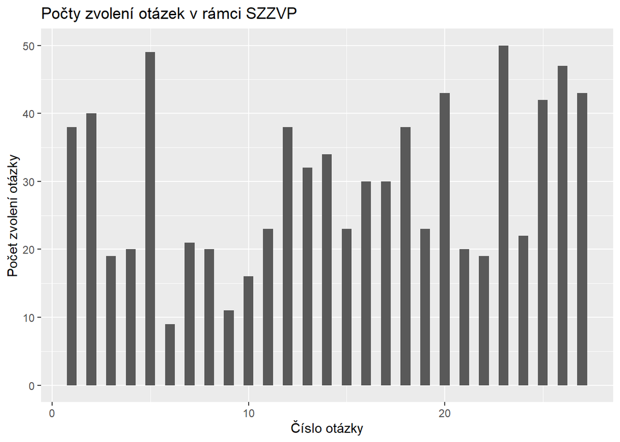

Nejméně oblíbené byly otázky:

| Elektronika a automatizace A | 9 |
| --- | --- |
| Elektronika a automatizace D | 11 |
| Elektronika a automatizace E | 16 |
| Počítačové zpracování signálu | 19 |
| Mikroekonomie a makroekonomie, stochastické modelování | 19 |